# Assessment

Answer the following questions with python using Jupyter notebook. You should include all the questions, your code, the outcome of the code and your answers in a single file, "html" or "PDF". Use the download as option from the file menu to do this. You can attach your *ipynb file as well, but make sure it works with outcomes.

# Question 1 [20%]

You have a data file called TCGA.csv, which has the gene expression dataset of some patients with liver cancer from the TCGA project.

**Using the data, complete the below tasks:**

- 1. Create a new data frame containing samples S15, S16, S17, S18, S19, S20 and gene columns.
- 2. Using the data in 1. above, add a new column called group by dividing the values of S18 into high and low based on the median value.
- 3. Extract the list of genes with values in S20 column lower than 10, and the group in 2 is high.
- 4. Create a new data frame from 2. above, with groups equal to low and values less than 3 in S16.
- 5. Create a scatter plot for the expression in S1 against S18 (apply log10 transformation to the plot).
- 6. Create a boxplot for expression in S19 against the group in data 2. above. Comment on your observation.

```python
#1
import pandas as pd
#numpy is for question 2
import numpy as np
# matplotlib.pyplot is for plotting
import matplotlib.pyplot as plt


Original_df= pd.read_csv('TCGA.csv')
df= Original_df.loc[:, ["S15","S16","S17","S18","S19","S20","gene"]]
df
```

|  | S15 | S16 | S17 | S18 | S19 | S20 | gene |
| --- | --- | --- | --- | --- | --- | --- | --- |
| 0 | 26.4968 | 20.8938 | 27.3609 | 29.0844 | 24.3038 | 24.1362 | A1BG |
| 1 | 132.7501 | 4.0627 | 336.4982 | 42.3940 | 300.7595 | 51.7409 | A1CF |
| 2 | 471.8068 | 121.0447 | 1354.0664 | 59.1628 | 1693.7975 | 91.8562 | A2LD1 |
| 3 | 57088.5470 | 41268.4910 | 15698.8341 | 38610.7374 | 17598.8304 | 30405.7241 | A2M |
| 4 | 1005.3252 | 1335.4614 | 765.6968 | 1833.2740 | 589.3671 | 957.8463 | A4GALT |
| ... | ... | ... | ... | ... | ... | ... | ... |
| 15548 | 1565.9950 | 1102.7280 | 1895.2530 | 883.8618 | 1757.4680 | 947.3065 | ZYG11B |
| 15549 | 2819.7030 | 4059.1990 | 1248.3920 | 3010.6880 | 1249.6200 | 5050.4910 | ZYX |
| 15550 | 1247.2420 | 1018.5720 | 1485.6560 | 619.5226 | 1318.4810 | 1458.0090 | ZZEF1 |
| 15551 | 901.4835 | 665.6994 | 951.0975 | 465.2654 | 878.9873 | 612.9067 | ZZZ3 |
| 15552 | 135.4127 | 68.4852 | 144.1552 | 26.7189 | 296.2025 | 123.2840 | psiTPTE22 |

15553 rows × 7 columns

```python
#2
S18_Median = df['S18'].median()
# first we add a column named group and then define every rows of it as "low"
df['Group'] = 'low'
#Then , we locate the rows that S18 is equal or higher than the median of column S18,
# and we change their Group to 'high'
df.loc[df['S18'] >= S18_Median , 'Group']= 'high'
df
```

|  | S15 | S16 | S17 | S18 | S19 | S20 | gene | Group |
| --- | --- | --- | --- | --- | --- | --- | --- | --- |
| 0 | 26.4968 | 20.8938 | 27.3609 | 29.0844 | 24.3038 | 24.1362 | A1BG | low |
| 1 | 132.7501 | 4.0627 | 336.4982 | 42.3940 | 300.7595 | 51.7409 | A1CF | low |
| 2 | 471.8068 | 121.0447 | 1354.0664 | 59.1628 | 1693.7975 | 91.8562 | A2LD1 | low |
| 3 | 57088.5470 | 41268.4910 | 15698.8341 | 38610.7374 | 17598.8304 | 30405.7241 | A2M | high |
| 4 | 1005.3252 | 1335.4614 | 765.6968 | 1833.2740 | 589.3671 | 957.8463 | A4GALT | high |
| ... | ... | ... | ... | ... | ... | ... | ... | ... |
| 15548 | 1565.9950 | 1102.7280 | 1895.2530 | 883.8618 | 1757.4680 | 947.3065 | ZYG11B | high |
| 15549 | 2819.7030 | 4059.1990 | 1248.3920 | 3010.6880 | 1249.6200 | 5050.4910 | ZYX | high |
| 15550 | 1247.2420 | 1018.5720 | 1485.6560 | 619.5226 | 1318.4810 | 1458.0090 | ZZEF1 | high |
| 15551 | 901.4835 | 665.6994 | 951.0975 | 465.2654 | 878.9873 | 612.9067 | ZZZ3 | high |
| 15552 | 135.4127 | 68.4852 | 144.1552 | 26.7189 | 296.2025 | 123.2840 | psiTPTE22 | low |

15553 rows × 8 columns

```python
#3
Extracted = df[(df['S20']<10) & (df['Group'] == 'high')]
# changing the type to a list:
Gene_List = Extracted['gene'].tolist()
print(Gene_List)
```

```
['CKMT2', 'CTXN3', 'GSTM1', 'HMGCS2', 'KLB', 'LGALS4', 'PAH', 'SORCS3', 'UMOD']
```

```python
#4 Create a new data frame from 2. above, with groups equal to low and values less than 3 in S16.
New_df = df[( df['Group'] == 'low' ) & ( df['S16']<3 )]
New_df
```

|  | S15 | S16 | S17 | S18 | S19 | S20 | gene | Group |
| --- | --- | --- | --- | --- | --- | --- | --- | --- |
| 25 | 1.5215 | 1.7411 | 18.3767 | 0.7125 | 6.0759 | 69.6267 | ABCA13 | low |
| 32 | 342.7159 | 2.3215 | 72.2818 | 6.4125 | 126.5823 | 439.4787 | ABCA6 | low |
| 117 | 31.1906 | 1.7411 | 22.4604 | 3.2063 | 27.3418 | 21.0796 | ACCN1 | low |
| 133 | 28.1476 | 1.1608 | 52.2716 | 0.0000 | 60.2532 | 0.0000 | ACOT12 | low |
| 187 | 29.6691 | 1.7411 | 31.0362 | 4.6313 | 38.4810 | 2.8745 | ACVR1C | low |
| ... | ... | ... | ... | ... | ... | ... | ... | ... |
| 14897 | 9.5093 | 1.1608 | 37.9786 | 3.5625 | 26.3291 | 6.7072 | ZCCHC16 | low |
| 15243 | 75.6942 | 2.9019 | 151.9142 | 2.4938 | 88.1013 | 1.2776 | ZNF488 | low |
| 15291 | 13.3130 | 0.0000 | 6.9423 | 1.7813 | 27.3418 | 8.9429 | ZNF556 | low |
| 15518 | 37.2765 | 1.7411 | 6.1256 | 0.3563 | 13.1646 | 6.0684 | ZPLD1 | low |
| 15547 | 38.4176 | 0.0000 | 109.0352 | 2.8500 | 89.6203 | 2.5551 | ZYG11A | low |

445 rows × 8 columns

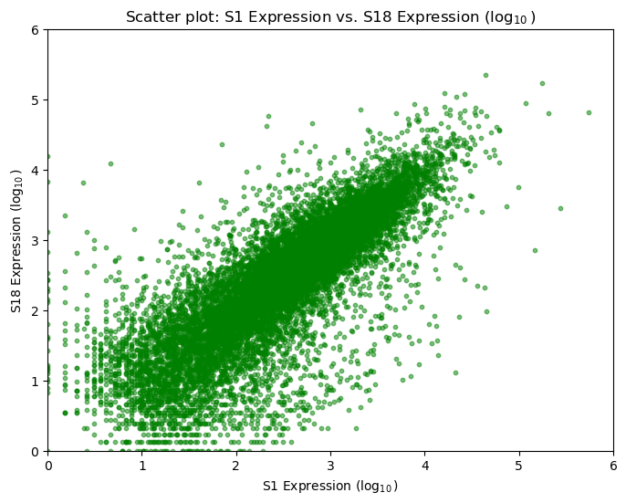

```python
#5 Create a scatter plot for the expression in S1 against S18 (apply log10 transformation to the plot).

#To make sure the plot will be under this block:
#%matplotlib inline

x_log = np.log10(Original_df['S1'] +1 )
y_log = np.log10(Original_df['S18'] +1 )

#Max_x = x.max()
#Max_y = y.max()
#Max_x
#Max_y
# The output for above codes:  Max_x ≈ 5.7 and the Max_y ≈ 5.3


# Now we can assign a value to the plot_limit
plot_limit = 6

fig, ax = plt.subplots(figsize=(8,6)) # This is the common figsize

ax.scatter(x_log, y_log, c="green", s=10,  alpha= 0.5) # size equals to 10 which means small and alpha is transparency
ax.set(xlim=(0, plot_limit), xticks=np.arange(0, plot_limit +1),
       ylim=(0, plot_limit), yticks=np.arange(0, plot_limit +1))

# Now we want to add title for our plot and names for axis
plt.title(r"Scatter plot: S1 Expression vs. S18 Expression ($\log_{10}$)")
plt.xlabel(r"S1 Expression ($\log_{10}$)")
plt.ylabel(r"S18 Expression ($\log_{10}$)")

plt.show()

plt.close() # to make sure there is one plot on the output , and tremoves


# ($\log_{10}$) This is the standard way for Matplotib plots.(LaTeX syntax)
# $ : switch into math mode
# \log : command for logarithm function
# _{10} : _ tells LaTeX that the following characters should be a subscript
```

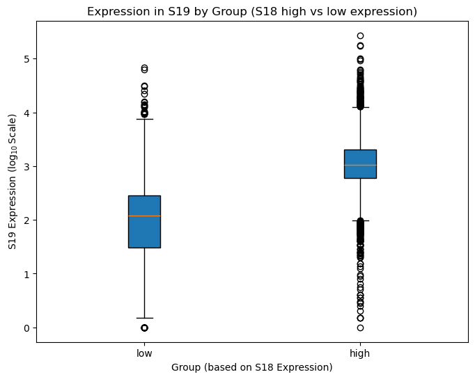

```
Group
high    272222.3000
low      69344.3038
Name: S19, dtype: float64
```

```
"\nThe main finding is that S18 and S19 have positive correlation. If gene S18 is highly expressed, gene S19 is usually \nhighly expressed too.\n\nWe split the samples into two groups: those with high S18 expression and those with low S18 expression.\nThe median is much higher in the 'high S18' grou…
```

```python
#6. Create a boxplot for expression in S19 against the group in data 2. above. Comment on your observation.

s19_low_log = np.log10(df[df['Group'] == 'low']['S19']+1).values # .values convert it to array because plt.boxplot() expects array as input
s19_high_log = np.log10(df[df['Group'] == 'high']['S19']+1).values

plt.figure(figsize=(8,6)) # common size

plt.boxplot(
    [s19_low_log,s19_high_log],
    tick_labels=['low','high'],
    patch_artist=True # solid color in the boxes

)


plt.title('Expression in S19 by Group (S18 high vs low expression)')
plt.xlabel('Group (based on S18 Expression)')
plt.ylabel(r'S19 Expression ($\log_{10}$Scale)')

plt.show()
plt.close()


max_s19_by_group= df.groupby('Group')['S19'].max()
print(max_s19_by_group)


"""
The main finding is that S18 and S19 have positive correlation. If gene S18 is highly expressed, gene S19 is usually
highly expressed too.

We split the samples into two groups: those with high S18 expression and those with low S18 expression.
The median is much higher in the 'high S18' group (around 1000) compared to the 'low S18' group (around 100).
Not only is the expression higher in the 'high S18', but also the highest expression point in the 'high' group(272222.3000)is
much greater than the highest expression point in the 'low' group (69344.3038)/ YOU CAN FIND THESE NUMBERS IN MY CODE!!!
Many low outliers exist in 'high' group, but they do not change our observation of a positive correlation,
as our observation is based on the central tendency (median and the box), not the scattered outliers.

In summary , S18 and S19 appear to be highly co-expressed - meaning they tend to turn on and turn off together.
"""
```

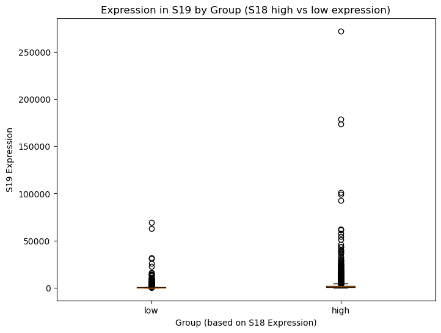

```
' I asked our classmates about this question and they mentioned since the question does not ask for logarithmic values, we should not \ntransform the data into log10 form.However, we need to explain why it is incorrect to present the plot without using \nthe logarithmic transformation.Below are my o…
```

```python
s19_low = df[df['Group'] == 'low']['S19']
s19_high = df[df['Group'] == 'high']['S19']

plt.figure(figsize=(8,6)) # common size

plt.boxplot(
    [s19_low,s19_high],
    tick_labels=['low','high'],
    patch_artist=True # solid color in the boxes

)


plt.title('Expression in S19 by Group (S18 high vs low expression)')
plt.xlabel('Group (based on S18 Expression)')
plt.ylabel('S19 Expression')

plt.show()
plt.close()


""" I asked our classmates about this question and they mentioned since the question does not ask for logarithmic values, we should not
transform the data into log10 form.However, we need to explain why it is incorrect to present the plot without using
the logarithmic transformation.Below are my observations:
This plot is not effective because the data covers a wide range of values, which causes visual problems.
Gene expression vary greatly .some of them are close to zero, while others are around 200,000 and above.
Therefore, the scale stretches to include all these values.
Conclusion:
The lower and middle parts of data get squeezed, making it impossible to see real differences
between the two groups or between values like 10 and 100.Therefore, we should use logarithmic scale instead of the linear scale.
"""
```

# Question 2 [30%]

**Write functions that do the following tasks:**

- 1. That takes a DNA sequence (for example "CCTGTCAAAAGATATGT") and converts it to an RNA sequence. Then returns the DNA sequence, the RNA sequence and the length of this sequence using a list. [Hint: Convert all the T in DNA to U to make RNA. Use the "string".repalce() method] [10%]
- 2. Write a function that takes the size of a chromosome and creates a non-overlapping window of a size specified by an argument. Therefore, chromosome size 100 and size 20 return 1-20, 21-40, 41-60, 61-80, 81-100. This function should have an optional argument to either print the result on the screen or not. [10%]
- 3. Write a function to determine the maximum of four numbers given as a tuple argument. [10%]

```python
#1
def dna_to_rna(DNA_Sequence):

    RNA_Sequence = DNA_Sequence.replace('T','U')
    Length = len(DNA_Sequence)
    return [DNA_Sequence,RNA_Sequence,Length]

DNA = "CCTGTCAAAAGATATGT"

result = dna_to_rna(DNA)
print(f"result: {result}")
print("\n")

#showing the results in a different way:
DNA = result[0]
RNA = result[1]
Length = result[2]
print(f"DNA: {DNA}")
print(f"RNA: {RNA}")
print(f"Length: {Length}")
```

```
result: ['CCTGTCAAAAGATATGT', 'CCUGUCAAAAGAUAUGU', 17]


DNA: CCTGTCAAAAGATATGT
RNA: CCUGUCAAAAGAUAUGU
Length: 17
```

```python
#2Write a function that takes the size of a chromosome and creates a non-overlapping window of a size specified by an argument. Therefore,
#chromosome size 100 and size 20 return 1-20, 21-40, 41-60, 61-80, 81-100.
#This function should have an optional argument to either print the result on the screen or not.

def create_non_overlapping_windows(
    chromosome_size: int,
    window_size: int,
    print_result: bool = False
):
    windows = []
    start_position = 1 #It is 1 , because the question defines it as 1

    while start_position <= chromosome_size:
        end_position = start_position + window_size - 1 #calculation of the intended end position

        #check if the end position is greater than chromosome size:

        if end_position > chromosome_size:
            end_position = chromosome_size

        # saving the current window:
        windows.append((start_position,end_position))
        # new start_position for the next window, it starts immediately after the current one ends
        start_position = end_position + 1

        #optional print argument:
        if print_result :
            print(f"Window: {start_position - window_size}-{end_position}") # as we updetaed the start_position in the former line
                                                                            # we should substract window_size to get the real start_positioon
    return windows




create_non_overlapping_windows(100,20,True)
```

```
Window: 1-20
Window: 21-40
Window: 41-60
Window: 61-80
Window: 81-100
```

```
[(1, 20), (21, 40), (41, 60), (61, 80), (81, 100)]
```

```python
#3.Write a function to determine the maximum of four numbers given as a tuple argument. [10%]
def max_of_four(input_tuple):
    if not isinstance(input_tuple,tuple) or len(input_tuple) != 4:
        print("Error!!!")#this line signals to the program that the input is invalid
        return None # The function immediately exits at this line,preventing it from executing any subsequent logic within the function.

    if input_tuple[1] > input_tuple[0]:
        max = input_tuple[1]
    else:
        max = input_tuple[0]
    if input_tuple[2] > max:
        max = input_tuple[2]
    if input_tuple[3] > max:
        max = input_tuple[3]
    return max



data = (12,33,41,12)

max_of_four(data)
```

```
41
```

# Question 3 [20%]

We have defined a Cell class below. Write a subclass called adTCell that extends the Cell class. It should have self.protein, self.size set to 1, and self.max_rate attributes. The self.protein attribute should be a list.

Code the following method:

1. .init(*****, size) constructor. Identify and include all the parameters to ensure that the cell .init() is included.
2. Set self.size to size and self.max_rate to 0.5
3. .add_protein() that takes a protein name as an argument and adds it to the self.protein attribute.
4. .summary() that prints the total number of organelle, genes and proteins.
5. .grow() that takes a growth rate argument and increases the self.size attribute by that rate if it is smaller than the self.max_rate, otherwise complain and do nothing.

```python
# This is the cell class to use for Question 3 above.

class Cell:
    """ A class representing a cell"""

    # Constructor
    def __init__(self, name):
        """Input layer"""
        self.name = name
        self.organelles = []    # creates a new empty list for each cell
        self.genes = []         # same as above

    # The string method
    def __str__(self):
        return ("A model of a cell, current instance is {} ".format(self.name))

    # Methods
    def add_organelle(self, organelle):
        self.organelles.append(organelle)

    def add_gene(self, gene):
        self.genes.append(gene)

    def view_cell(self):
        return self.organelles, self.genes
```

```python
class Cell:
    """ A class representing a cell"""

    # Constructor
    def __init__(self, name):
        """Input layer"""
        self.name = name
        self.organelles = []    # creates a new empty list for each cell
        self.genes = []         # same as above

    # The string method
    def __str__(self):
        return ("A model of a cell, current instance is {} ".format(self.name))

    # Methods
    def add_organelle(self, organelle):
        self.organelles.append(organelle)

    def add_gene(self, gene):
        self.genes.append(gene)

    def view_cell(self):
        return self.organelles, self.genes

class adTCell(Cell):
    def __init__(self, name, size=1):
        Cell.__init__(self, name)
        self.protein = []
        self.size = size
        self.max_rate = 0.5

    def add_protein(self, protein_name):
        self.protein.append(protein_name)

    def summary(self):
        print(f"""
---Summry for {self.name} ---
Total Organeles: {len(self.organelles)}
Total Genes: {len(self.genes)}
Total Proteins: {len(self.protein)}
""")

    def grow(self, growth_rate):
        if growth_rate < self.max_rate:
            self.size += growth_rate
            print(f"{self.name} grew by {growth_rate} /New Size: {self.size}")

        else:
            print(f"Growth rate {growth_rate} is larger than maximum growth rate {self.max_rate}. The cell cannot grow !")


tCell = adTCell("CD8_T_cell" , 1.0)
tCell.add_organelle("Mitochondrion")
tCell.add_gene("CD3G")
tCell.add_protein("Interleukin-2 (IL-2)")
tCell.summary()
tCell.grow(0.3)
tCell.grow(0.8)
```

```
---Summry for CD8_T_cell ---
Total Organeles: 1
Total Genes: 1
Total Proteins: 1

CD8_T_cell grew by 0.3 /New Size: 1.3
Growth rate 0.8 is larger than maximum growth rate 0.5. The cell cannot grow !
```

# Question 4 [30%]

In your R assessment 3 you were asked to do functions to perform some tasks. Please, convert the R code for the below question to the python code to do the same tasks.

Write functions that can do the following:

- 1. Take a string containing a DNA sequence, and convert this to a vector, which each entry is one base. a. Calculate the length of the sequences. b. The amount of each of the four nucleotides, A, T, G and C. c. Return these as a tuple with each item named (i.e. length, A, T, G, C) [15%]
- 2. Write a function that takes a DNA sequence and substitutes one nucleotide specified by an argument (default value “A”) for another nucleotide specified by an argument (default value “T”, in other words, the default of this function changes “A” to “T”). This function should return a dictionary with both the original and the new string of nucleotides. [15%]

```python
#1
exampleDNASequence = "TTGGTCATCCTAGACACGCGCCCTACCTGTCAAAATCTAAAATTCATCATACCCTGCGGACGGTGCTTCTGTGCCGAGGCGCAGGCCGATATGTTTCTAC"
def one_base_vector(dna_string):
    nucleotides = list(dna_string)
    return nucleotides

print(one_base_vector(exampleDNASequence))
```

```
['T', 'T', 'G', 'G', 'T', 'C', 'A', 'T', 'C', 'C', 'T', 'A', 'G', 'A', 'C', 'A', 'C', 'G', 'C', 'G', 'C', 'C', 'C', 'T', 'A', 'C', 'C', 'T', 'G', 'T', 'C', 'A', 'A', 'A', 'A', 'T', 'C', 'T', 'A', 'A', 'A', 'A', 'T', 'T', 'C', 'A', 'T', 'C', 'A', 'T', 'A', 'C', 'C', 'C', 'T', 'G', 'C', 'G', 'G', 'A',…
```

```python
#a: Calculate the length of the sequences. b. The amount of each of the four nucleotides, A, T, G and C.
#c. Return these as a tuple with each item named (i.e. length, A, T, G, C)
from collections import namedtuple

SequenceInfo = namedtuple(
    'SequenceInfo',
    ['Length','A','T','C','G']
)

def sequence_info(dna_string):
    Length = len(dna_string)
    countA = dna_string.count("A")
    countT = dna_string.count("T")
    countC = dna_string.count("C")
    countG = dna_string.count("G")

    return SequenceInfo(Length = Length, A = countA, T = countT, C= countC, G =countG)



exampleDNASequence = "TTGGTCATCCTAGACACGCGCCCTACCTGTCAAAATCTAAAATTCATCATACCCTGCGGACGGTGCTTCTGTGCCGAGGCGCAGGCCGATATGTTTCTAC"

sequence_info(exampleDNASequence)
```

```
SequenceInfo(Length=100, A=22, T=26, C=30, G=22)
```

```python
#Write a function that takes a DNA sequence and substitutes one nucleotide specified by an argument (default value “A”) for another nucleotide
#specified by an argument (default value “T”, in other words, the default of this function changes “A” to “T”). This function should return a
#dictionary with both the original and the new string of nucleotides.

def subsitute_nucleotide(dna_sequence : str, old_nuc: str = "A", new_nuc: str = "T"):

    Orginal_dna = dna_sequence
    new_sequence = dna_sequence.replace(old_nuc, new_nuc)

    return{
        "Orginal_DNA_Sequence": Orginal_dna,
        "New_Sequence": new_sequence
    }




exampleDNASequence = "TTGGTCATCCTAGACACGCGCCCTACCTGTCAAAATCTAAAATTCATCATACCCTGCGGACGGTGCTTCTGTGCCGAGGCGCAGGCCGATATGTTTCTAC"

subsitute_nucleotide(exampleDNASequence)
```

```
{'Orginal_DNA_Sequence': 'TTGGTCATCCTAGACACGCGCCCTACCTGTCAAAATCTAAAATTCATCATACCCTGCGGACGGTGCTTCTGTGCCGAGGCGCAGGCCGATATGTTTCTAC',
 'New_Sequence': 'TTGGTCTTCCTTGTCTCGCGCCCTTCCTGTCTTTTTCTTTTTTTCTTCTTTCCCTGCGGTCGGTGCTTCTGTGCCGTGGCGCTGGCCGTTTTGTTTCTTC'}
```